# Análisis de varianza y Análisis de Componentes Principales (PCA)

## 2. Análisis de la varianza

#### 2.1. Lee el fichero de datos “decathlon.csv” y guarda los datos en un objeto con identificador ‘decath’

```r
#decath <- read_csv("F:/Mineria de datos/PEC3/decathlon.csv")
decath <- read.csv("F:/Mineria de datos/PEC3/decathlon.csv", encoding="UTF-8", header=TRUE, sep=",", na.strings="NA", dec=".", strip.white=TRUE)
```

#### 2.2. Consulta el resumen del conjunto de datos y el tipo de datos

```r
summary(decath)
```

```
##       X100           Xlong           Xpeso          Xaltura
##  Min.   :10.62   Min.   :6.220   Min.   :10.27   Min.   :1.790
##  1st Qu.:11.02   1st Qu.:7.000   1st Qu.:13.15   1st Qu.:1.940
##  Median :11.18   Median :7.090   Median :14.12   Median :1.970
##  Mean   :11.20   Mean   :7.133   Mean   :13.98   Mean   :1.983
##  3rd Qu.:11.43   3rd Qu.:7.370   3rd Qu.:14.97   3rd Qu.:2.030
##  Max.   :11.57   Max.   :7.720   Max.   :16.60   Max.   :2.270
##       X400            X110           Xdisc          Xpertig
##  Min.   :47.44   Min.   :14.18   Min.   :34.36   Min.   :4.000
##  1st Qu.:48.34   1st Qu.:14.72   1st Qu.:39.08   1st Qu.:4.600
##  Median :49.15   Median :15.00   Median :42.32   Median :4.700
##  Mean   :49.28   Mean   :15.05   Mean   :42.35   Mean   :4.739
##  3rd Qu.:49.98   3rd Qu.:15.38   3rd Qu.:44.80   3rd Qu.:4.900
##  Max.   :51.28   Max.   :16.20   Max.   :50.66   Max.   :5.700
##      Xjaval          X1500           score         pais
##  Min.   :49.52   Min.   :256.6   Min.   :6907   ESP  :11
##  1st Qu.:55.42   1st Qu.:266.4   1st Qu.:7579   FRANC:11
##  Median :59.48   Median :272.1   Median :7869   ITA  :11
##  Mean   :59.44   Mean   :276.0   Mean   :7857
##  3rd Qu.:64.00   3rd Qu.:286.0   3rd Qu.:8180
##  Max.   :72.60   Max.   :303.2   Max.   :8488
```

```r
class(decath)
```

```
## [1] "data.frame"
```

#### 2.3. Realiza un gáfico boxplot del score para cada pais.

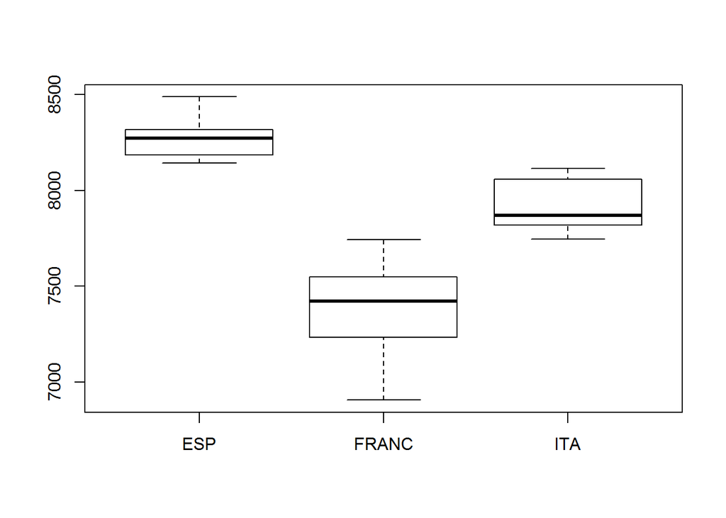

```r
boxplot(decath$score~decath$pais)
```

#### 2.4. Una vez preparado el data.frame realiza un análisis de la varianza (ANOVA) para determinar si existen diferencias en las medias de las puntuaciones para los distintos países. Se puede utilizar la función aov.

```r
decath.df <- as.data.frame(cbind(decath$pais,decath$score))
names(decath.df) <- c("pais", "score")
decath.df$score <- as.character(decath.df$score)
decath.df$score <- as.numeric(decath.df$score)
myaov <- aov( decath.df$score~decath.df$pais, decath.df )
myaov
```

```
## Call:
##    aov(formula = decath.df$score ~ decath.df$pais, data = decath.df)
##
## Terms:
##                 decath.df$pais Residuals
## Sum of Squares          642618   4870427
## Deg. of Freedom              1        31
##
## Residual standard error: 396.3717
## Estimated effects may be unbalanced
```

```r
summary(myaov)
```

```
##                Df  Sum Sq Mean Sq F value Pr(>F)
## decath.df$pais  1  642618  642618    4.09 0.0518 .
## Residuals      31 4870427  157111
## ---
## Signif. codes:  0 '***' 0.001 '**' 0.01 '*' 0.05 '.' 0.1 ' ' 1
```

```r
#calculamos el valor crítico.
qf(0.05 , 2, 30 , lower.tail = F )
```

```
## [1] 3.31583
```

```r
write.csv(decath.df, file="decathlondf.csv")
```

#### 2.7 Finalmente, Calculamos el valor de F, considerando los grados de libertad en el numerador (k-1) y en el denominador (N-k), siendo k el número de grupos y N el número de muestras totales.

Se adjunta documento Excell con comprobación. “Anova Test.xlsx”

## 3. Análisis de componentes principales

#### 3.1 Vamos a preparar los datos para la minería de datos. En primer lugar, debemos excluir de la base de datos decath las variables score y pais

```r
decath.com <- decath[,-(11:12)]
```

#### 3.2 Calcular el modelo PCA y mostrar los resultados. Usar la función prcomp

```r
prdecath.com <- prcomp(decath.com)
summary(prdecath.com)
```

```
## Importance of components:
##                            PC1    PC2     PC3     PC4     PC5     PC6
## Standard deviation     13.7807 5.8043 2.96066 0.94062 0.69811 0.34653
## Proportion of Variance  0.8116 0.1440 0.03746 0.00378 0.00208 0.00051
## Cumulative Proportion   0.8116 0.9555 0.99300 0.99678 0.99886 0.99938
##                            PC7     PC8    PC9    PC10
## Standard deviation     0.24744 0.23147 0.1563 0.08279
## Proportion of Variance 0.00026 0.00023 0.0001 0.00003
## Cumulative Proportion  0.99964 0.99987 1.0000 1.00000
```

#### 3.3 En el apartado anterior las variables no están estandarizadas, lo que provoca que el resultado esté afectado por la escala en que estan expresadas las mismas. Calcular el modelo PCA y comparar los resultados con variables estandarizadas. Interpreta los resultados.

```r
scaledecath.com <- scale(decath.com)
scaleprdecath.com <- prcomp(scaledecath.com)
scaleprdecath.com
```

```
## Standard deviations:
##  [1] 1.8488478 1.6144328 0.9712345 0.9370279 0.7460742 0.7008762 0.6561975
##  [8] 0.5538936 0.5166715 0.3191460
##
## Rotation:
##                PC1        PC2         PC3         PC4          PC5
## X100    -0.4158823  0.1488081 -0.26747198  0.08833244 -0.442314456
## Xlong    0.3940515 -0.1520815 -0.16894945  0.24424963  0.368913901
## Xpeso    0.2691057  0.4835374  0.09853273  0.10776276 -0.009754680
## Xaltura  0.2122818  0.0278985 -0.85498656 -0.38794393 -0.001876311
## X400    -0.3558474  0.3521598 -0.18949642 -0.08057457  0.146965351
## X110    -0.4334816  0.0695682 -0.12616012  0.38229029 -0.088802794
## Xdisc    0.1757923  0.5033347  0.04609969 -0.02558404  0.019358607
## Xpertig  0.3840821  0.1495820  0.13687235 -0.14396548 -0.716743474
## Xjaval   0.1799436  0.3719570 -0.19232803  0.60046566  0.095582043
## X1500   -0.1701426  0.4209653  0.22255233 -0.48564231  0.339772188
##                 PC6        PC7          PC8         PC9        PC10
## X100     0.03071237  0.2543985 -0.663712826  0.10839531 -0.10948045
## Xlong   -0.09378242  0.7505343 -0.141264141 -0.04613910 -0.05580431
## Xpeso    0.23002054 -0.1106637 -0.072505560 -0.42247611 -0.65073655
## Xaltura  0.07454380 -0.1351242  0.155435871  0.10206505 -0.11941181
## X400    -0.32692886  0.1413388  0.146839303 -0.65076229  0.33681395
## X110     0.21049130  0.2725296  0.639003579  0.20723854 -0.25971800
## Xdisc    0.61491241  0.1439726 -0.009400445  0.16724055  0.53450315
## Xpertig -0.34776037  0.2732665  0.276873049  0.01766443  0.06589572
## Xjaval  -0.43744387 -0.3419099 -0.058519366  0.30619617  0.13093187
## X1500   -0.30032419  0.1868704 -0.007310045  0.45688227 -0.24311846
```

```r
summary(scaleprdecath.com)
```

```
## Importance of components:
##                           PC1    PC2     PC3    PC4     PC5     PC6
## Standard deviation     1.8488 1.6144 0.97123 0.9370 0.74607 0.70088
## Proportion of Variance 0.3418 0.2606 0.09433 0.0878 0.05566 0.04912
## Cumulative Proportion  0.3418 0.6025 0.69679 0.7846 0.84026 0.88938
##                            PC7     PC8     PC9    PC10
## Standard deviation     0.65620 0.55389 0.51667 0.31915
## Proportion of Variance 0.04306 0.03068 0.02669 0.01019
## Cumulative Proportion  0.93244 0.96312 0.98981 1.00000
```

De la comporación podemos apreciar la notable diferencia en las desviaciones estandar calculadas. En el cálculo sin estandarizar vemos en su PC1 una desviación de 13.78 con una explicación del 99% de la variable X1500, evidentemente el que esta variable sea la de mayor cantidad numérica ha provocado que el primer analisis se halla visto influenciada por ella y le ha hecho seleccionarla para el primer componente “PC1” acreditando un 81% de explicación total y un acumulado de 95.5% para el PC2.

Los porcentajes de variabilidad calculados para los componentes son: PC1=34%, PC2=26%, PC3=9.4%, PC4=8.7%, PC5=5.5%, PC6=4.9%, PC7=4.3%, PC8=3%, PC9=2.6%, PC10=1%.

```r
decath1.4 <- predict(scaleprdecath.com)[,1:4]
decath1.4
```

```
##               PC1         PC2          PC3         PC4
##  [1,]  1.73296107  1.23136956 -2.790893888 -0.29003667
##  [2,]  2.78724065 -0.10067980  0.838411902  0.13433649
##  [3,]  1.87922186 -0.13689245  0.044591942  0.97006947
##  [4,]  2.31314542  0.79457326  0.346892077 -0.25951896
##  [5,]  2.26071004 -2.01911115  0.481058734  0.07332298
##  [6,]  2.67521679 -1.43254232 -0.522420319 -1.64275774
##  [7,]  1.61935352  0.98919014  0.080941001 -1.59381967
##  [8,]  1.53547237 -0.12902356  0.288348858  0.13154800
##  [9,]  1.14787752  0.44461098 -0.496723823  0.46373008
## [10,]  1.42944513  1.61846748  0.804696781 -0.69026930
## [11,]  1.59225861  1.34447510  0.494195798 -0.27045583
## [12,]  0.75777818 -0.14353345 -0.190133530  1.84232486
## [13,]  1.21315646 -1.90970352 -0.593973402 -0.08029912
## [14,]  1.22404537 -0.63269414  0.002654759  1.18962886
```

[output cut: 19 more lines]

#### 3.6 Analiza correlación entre los valores del conjunto de datos para las primeras cuatro componentes calculadas en el apartado anterior y la variable score. Calcula el coeficiente de correlación de pearson. Realiza un gráfico que relacione cada componente con la variable y score. Interpreta los resultados obtenidos.

```r
#options(scipen = 999) # Evitamos la notación científica
decath1.4 <- as.data.frame(cbind(decath1.4,decath[,11]))
names(decath1.4) <-c("PC1","PC2","PC3","PC4","score")
cor(decath1.4)
```

```
##                 PC1           PC2           PC3           PC4       score
## PC1    1.000000e+00  1.669615e-16 -1.899331e-16  1.117889e-16  0.96158388
## PC2    1.669615e-16  1.000000e+00 -4.700147e-16  1.409705e-16  0.16194195
## PC3   -1.899331e-16 -4.700147e-16  1.000000e+00 -1.834134e-16 -0.15845281
## PC4    1.117889e-16  1.409705e-16 -1.834134e-16  1.000000e+00  0.09058519
## score  9.615839e-01  1.619420e-01 -1.584528e-01  9.058519e-02  1.00000000
```

De los resultados del análisis de correlación podemos apreciar que los componentes principales no están correlacionados entre ellos, prueba evidente de que el PCA evita informacción reduntante.

Es significativa la correlación presentada entre PC1 y la variable score siendo esta de un 96% hecho que asegura una relación lineal entre ellas. Podemos apreciar esta relación en el siguiente gráfico.

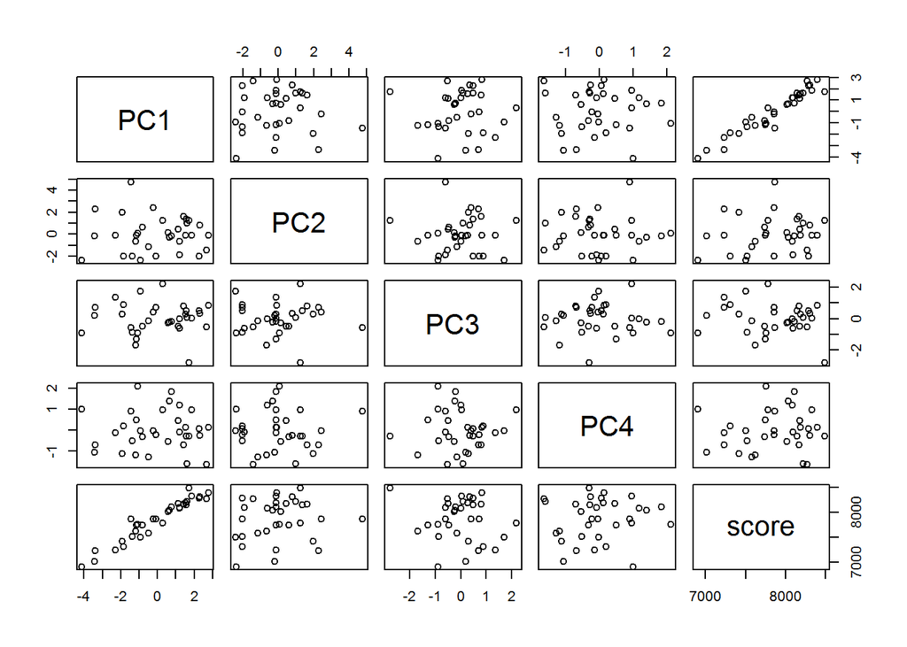

```r
pairs(decath1.4)
```

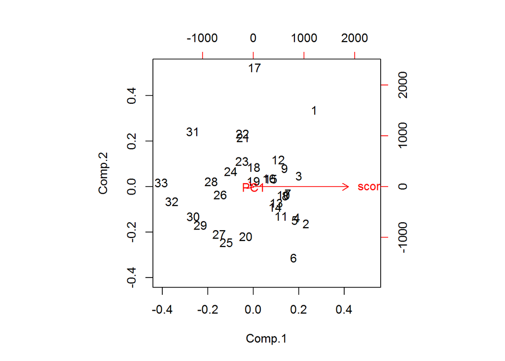

```r
decathscore1 <- as.data.frame(cbind(decath1.4[,1],decath1.4[,5]))
names(decathscore1) <-c("PC1","score")
decathscore2 <- as.data.frame(cbind(decath1.4[,2],decath1.4[,5]))
names(decathscore2) <-c("PC2","score")
decathscore3 <- as.data.frame(cbind(decath1.4[,3],decath1.4[,5]))
names(decathscore3) <-c("PC3","score")
decathscore4 <- as.data.frame(cbind(decath1.4[,4],decath1.4[,5]))
names(decathscore4) <-c("PC4","score")

biplot(princomp(decathscore1))
```

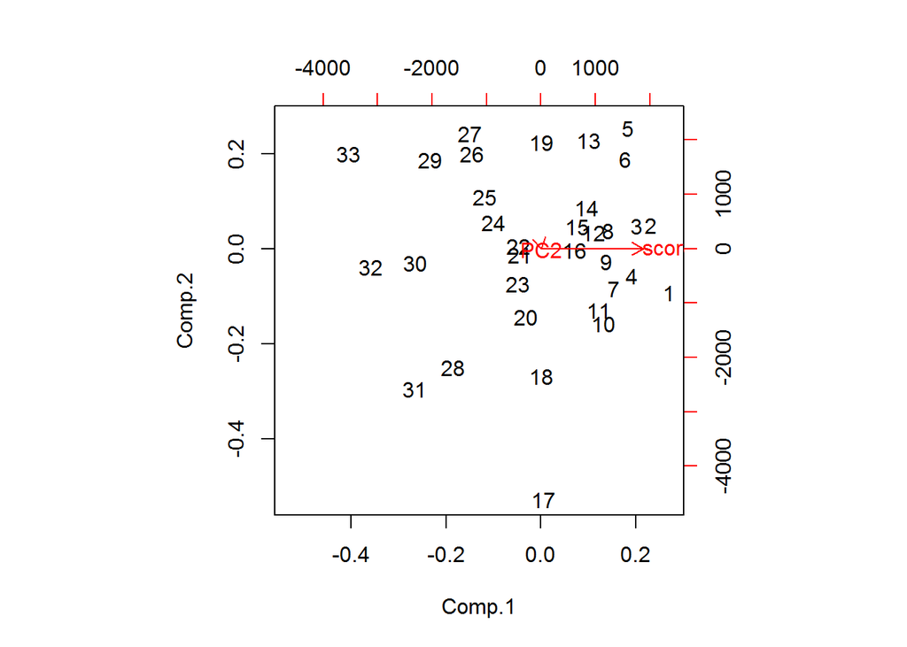

```r
biplot(princomp(decathscore2))
```

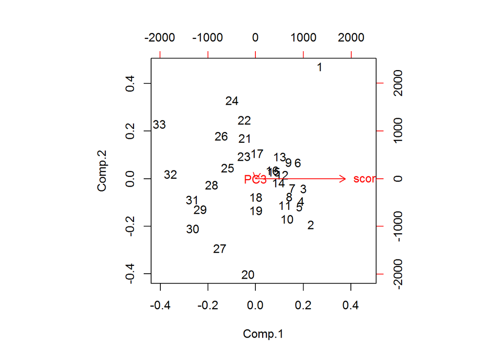

```r
biplot(princomp(decathscore3))
```

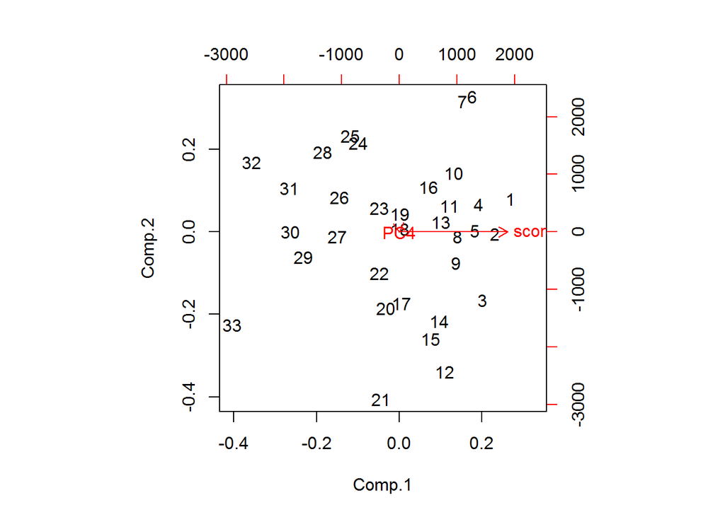

```r
biplot(princomp(decathscore4))
```